# Práctica 2: Probabilidad, muestras y población

# 1. Variables aleatorias con distribución conocida

En **R** existen comandos para el cálculo de probabilidades con función de distribución conocida. En el caso de las distribuciones discretas que hemos visto, tenemos la distribución binomial $binom$, Poisson $pois$ y Geométrica $geom$. Entre algunas de las funciones de distribuciones contínuas se encuentran la distribución Normal $norm$, t-Student $t$, $\chi^2$ $chisq$, F-Snedecor $f$.

Por ejemplo, si dada una variable aleatoria $X_1 \sim Po(\lambda=2)$ queremos calcular $P(X_1= 4)$,

```r
dpois(4,2)
```

```
## [1] 0.09022352
```

Si en cambio, dada la variable aleatoria $X_2 \sim Bi(n=5,p=0.25)$, queremos conocer la $P(X_2\leq 2)$

```r
pbinom(2,size=5,prob=0.25)
```

```
## [1] 0.8964844
```

Para calcular una muestra aleatoria de una $N(\mu=22,\sigma=7)$ y dibujarla tendríamos que hacer:

```r
sample10<-rnorm(10,22,7)
sample10
hist(sample10,freq = FALSE, col = "blue")
```

[output not shown]

Con ayuda del **R** podemos calcular las gráficas de las funciones de probabilidad y de distribución. Por ejemplo, para $X\sim Bi(5,0.2)$:

- Función de probabilidad

```r
x <- 0:5
plot(x, dbinom(x, 5,0.2), xlab="x", ylab="probabilidad",
     main="Función de probabilidad, Bi(5,0.2)", type="h")
  points(x, dbinom(x, 5, 0.2), pch=16)
abline(h=0, col="gray")
```

[output not shown]

```r
remove(x)
```

- Función de distribución:

```r
 x <- 0:5
 x <- rep(x, rep(2, length(x)))
    plot(x[-1], pbinom(x, 5,0.2)[-length(x)], xlab="x", ylab="probabilidad",
     main="Función de distribución, Bi(5,0.2)", type="l")
  abline(h=0, col="gray")
```

[output not shown]

```r
 remove(x)
```

Análogamente en el caso de funciones contínuas como una distrubución $N(50,10)$:

- Función de densidad

```r
 x <- seq(10,90 , length=100)
    plot(x, dnorm(x, mean=50, sd=10), xlab="x", ylab="densidad",
  main="Normal(mu=50, sigma=10)", type="l")
 abline(h=0, col="gray")
```

[output not shown]

```r
 remove(x)
```

- Función de distribución:

```r
 x <- seq(10, 90, length=100)
    plot(x, pnorm(x, mean=50, sd=10), xlab="x", ylab="probabilidad",
  main="Normal(mu=50, sigma=10)", type="l")
 abline(h=0, col="gray")
```

[output not shown]

```r
 remove(x)
```

*Apartado a*

```r
pnorm(36,40,5)*100
```

```
## [1] 21.18554
```

*Apartado b.1*

```r
pbinom(1, 4, pnorm(36,40,5), lower.tail = FALSE)
```

```
## [1] 0.1992705
```

*Apartado b.2*

Emplearemos que si $X_i\sim N(\mu_i, \sigma_i)$ y $\alpha_i \in \mathbb{R}$, $i=1,2,...n$ entonces
$$Y=\sum_{i=1}^n \alpha_ix_i\sim N\left(\sum_{i=1}^n \alpha_i \mu_i, \sqrt{\sum_{i=1}^n\alpha_i^2\sigma_i^2}\right)$$
Por lo tanto, la media que estamos estudiando seguirá una distribución
$$\frac{1}{4}(X_1+X_2+X_3+X_4)\sim N\left(\frac{1}{4}\cdot 4\cdot 40, \sqrt{\sum_{i=1}^4 \frac{1}{4^2}\cdot 5^2}\right)=N\left(40, \frac{5}{2}\right)$$

```r
pnorm(36, mean=40, sd=5/2)
```

```
## [1] 0.05479929
```

*Apartado c*

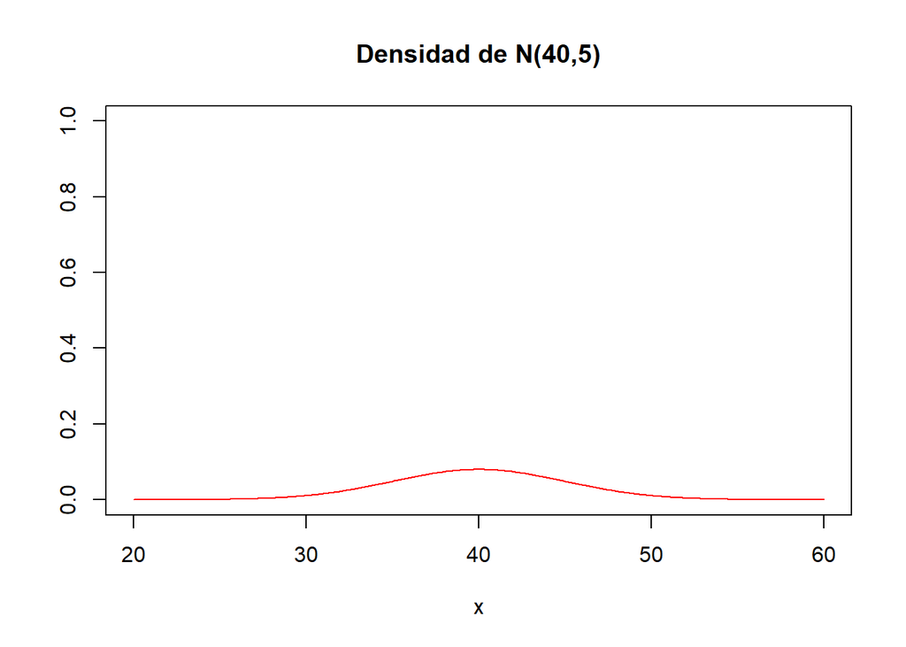

```r
x<-seq(20, 60, 0.1)
z<-0:4
zlargo<-rep(z, rep(2, length(z)))

plot(x, dnorm(x, mean=40, sd=5), type="l", ylim=c(0,1), ylab="", col="red", main="Densidad de N(40,5)")
```

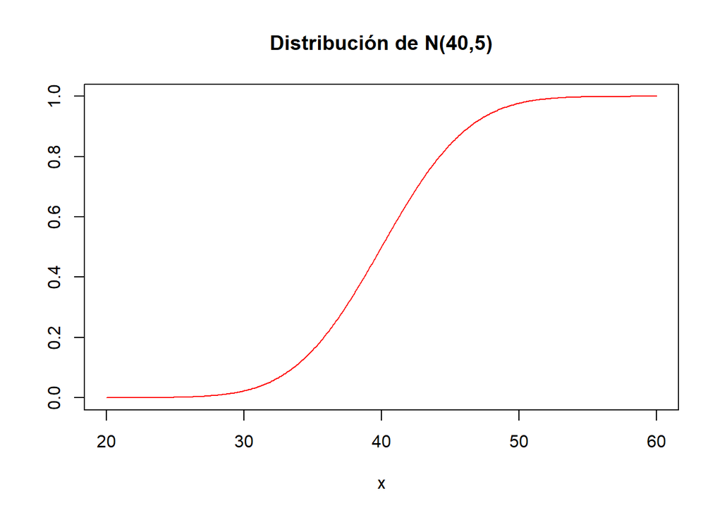

```r
plot(x, pnorm(x, mean=40, sd=5), type="l", ylim=c(0,1), ylab="", col="red", main="Distribución de N(40,5)")
```

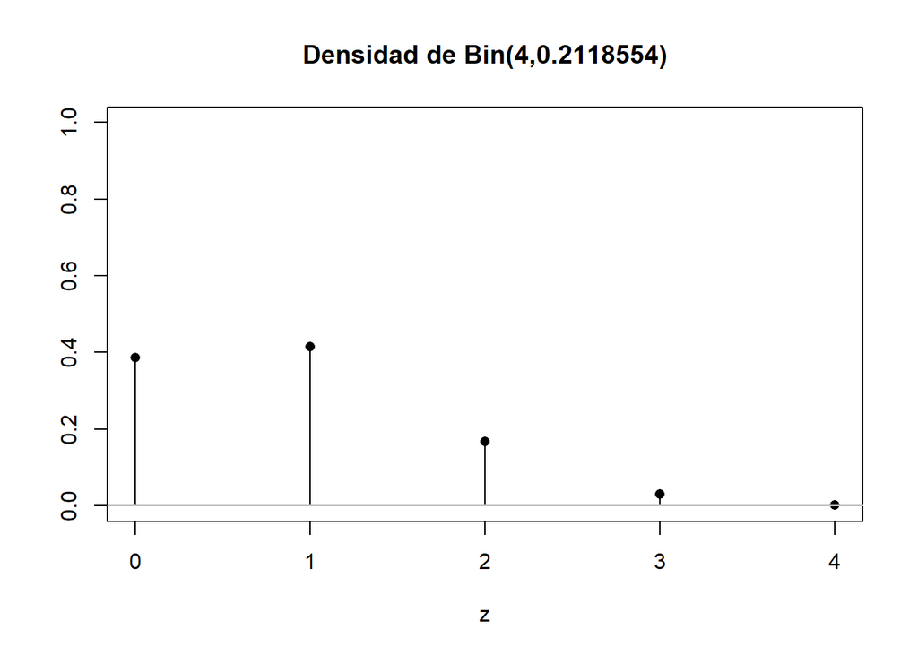

```r
plot(z, dbinom(z, size=4, prob=pnorm(36,40,5)), ylim=c(0,1), ylab="", main="Densidad de Bin(4,0.2118554)", type="h")
points(z, dbinom(z, 4, pnorm(36,40,5)), pch=16)
abline(h=0, col="gray")
```

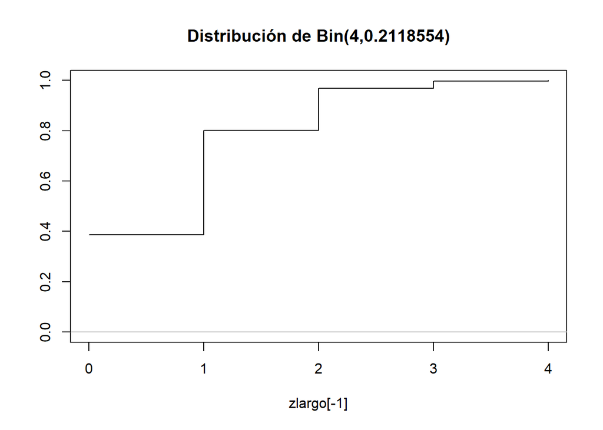

```r
plot(zlargo[-1], pbinom(zlargo, size=4, prob=pnorm(36,40,5))[-length(zlargo)], ylim=c(0,1), ylab="", main="Distribución de Bin(4,0.2118554)", type="l")
abline(h=0, col="gray")
```

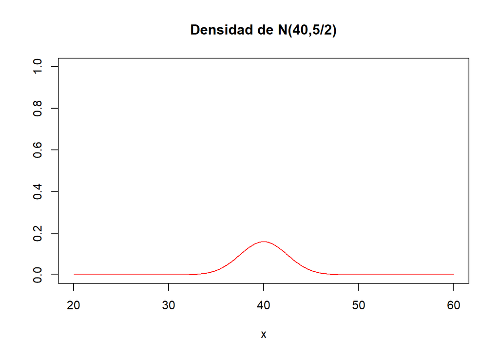

```r
plot(x, dnorm(x, mean=40, sd=5/2), type="l", ylim=c(0,1), ylab="", col="red", main="Densidad de N(40,5/2)")
```

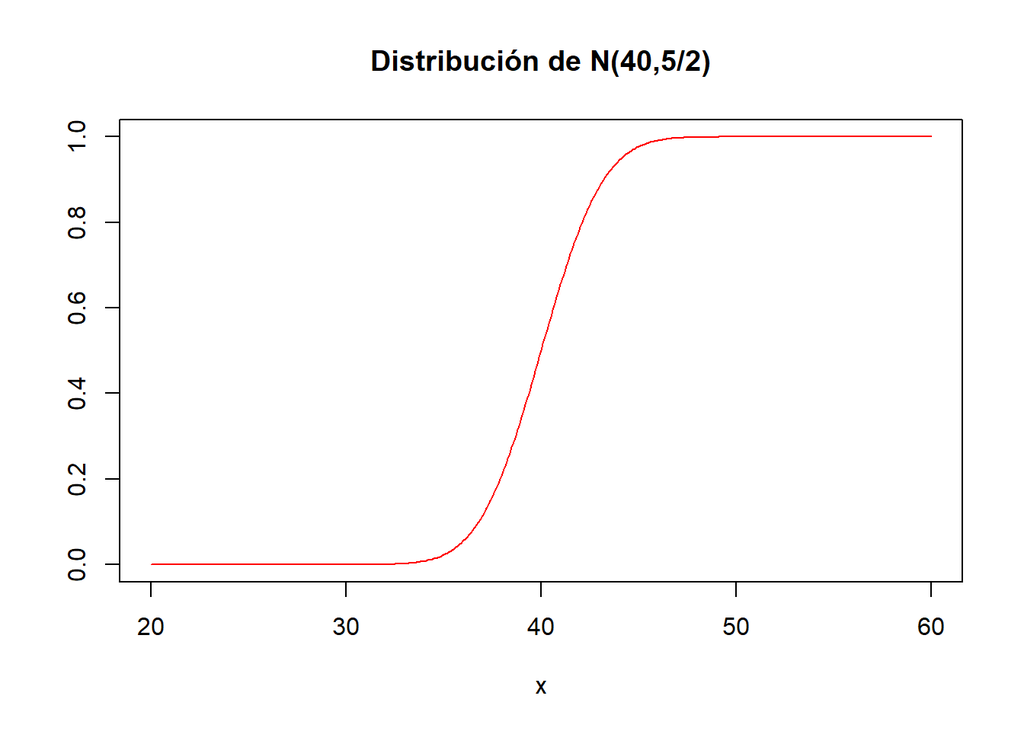

```r
plot(x, pnorm(x, mean=40, sd=5/2), type="l", ylim=c(0,1), ylab="", col="red", main="Distribución de N(40,5/2)")
```

# 2. Muestras y población

**Ejercicio 2.** Genera 100, 500, 1000, 5000 observaciones de una población $N(0,1)$. Dibuja el histograma de cada una de ellas. Y añade en cada una de ellas la gráfica de la función de densidad de $N(0,1)$. Calcula la media y desviación típica de cada una de las muestras generadas y compáralas con la media y desviación típica poblacional. Razona qué observas.

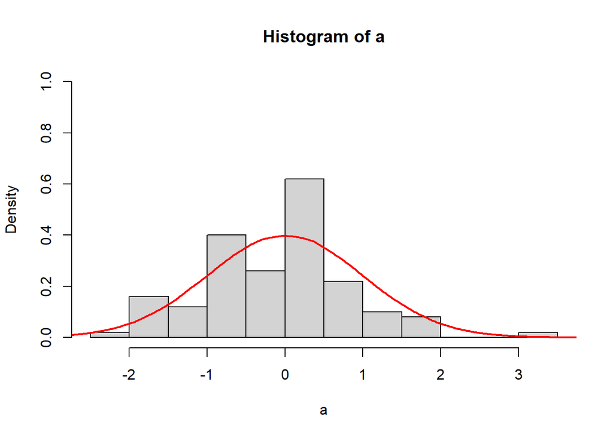

```r
a<-rnorm(100)
b<-rnorm(500)
c<-rnorm(1000)
d<-rnorm(5000)
e<-rnorm(1000000)

hist(a, freq=FALSE, ylim=c(0,1))
lines(density(e), lwd=2, col="red")
```

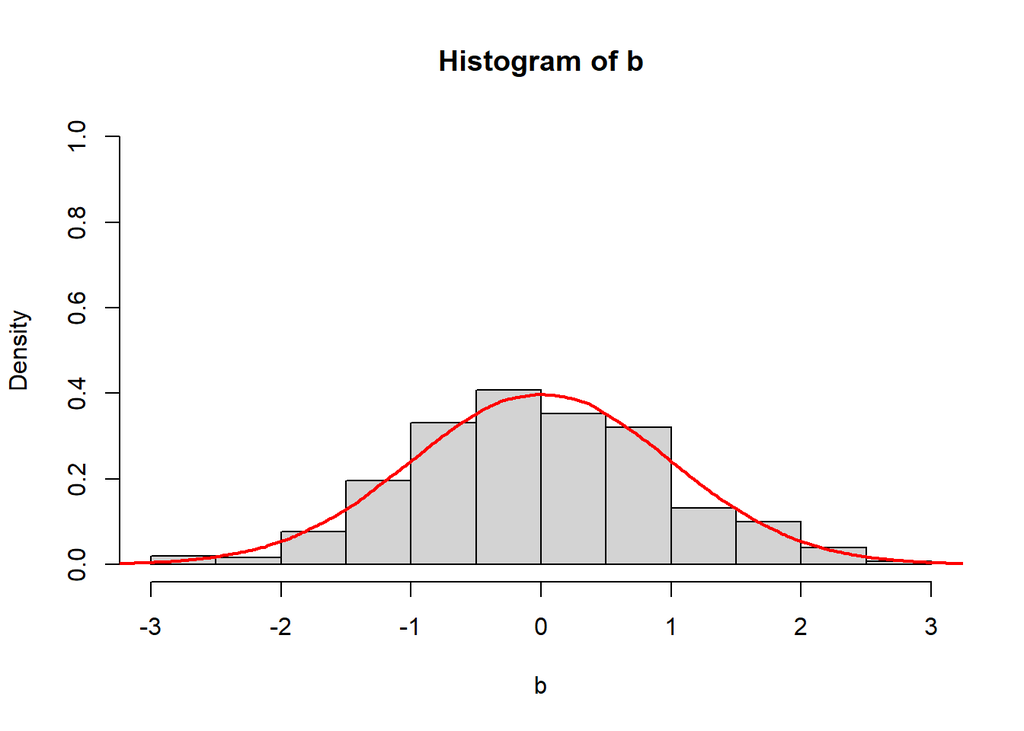

```r
hist(b, freq=FALSE, ylim=c(0,1))
lines(density(e), lwd=2, col="red")
```

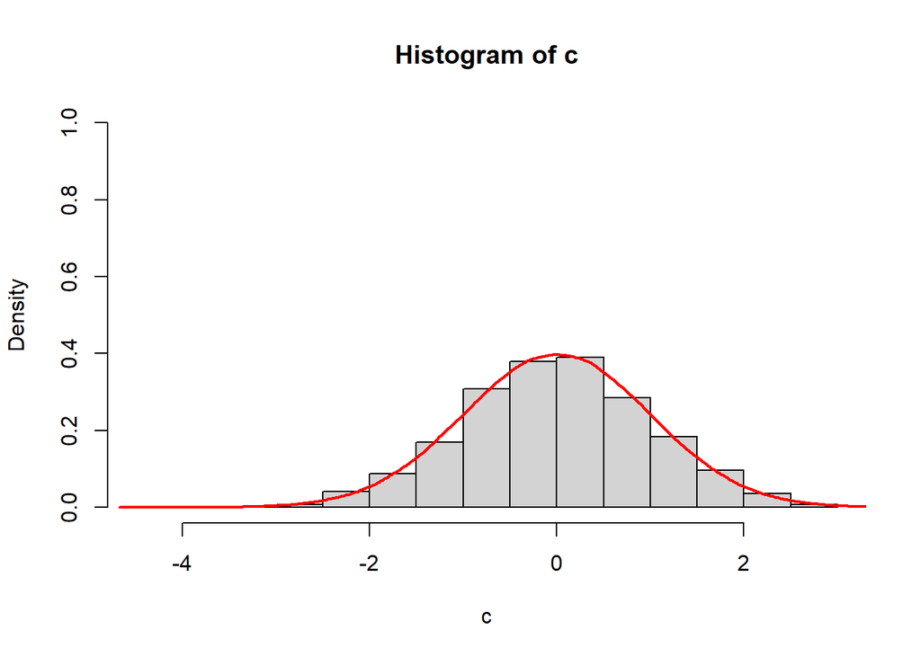

```r
hist(c, freq=FALSE, ylim=c(0,1))
lines(density(e), lwd=2, col="red")
```

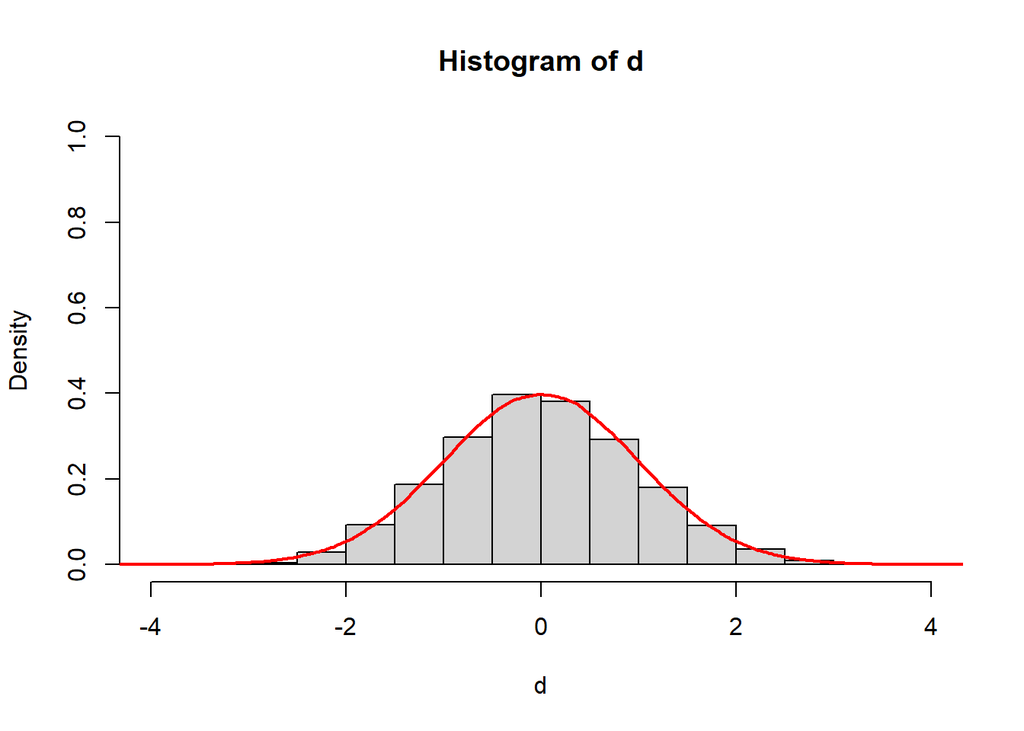

```r
hist(d, freq=FALSE, ylim=c(0,1))
lines(density(e), lwd=2, col="red")
```

```r
Media<-sapply(list(a,b,c,d), mean)
Desviacion<-sapply(list(a,b,c,d), sd)
g<-rbind(Media,Desviacion)
colnames(g)<-c("100", "500", "1000", "5000")
g
```

```
##                    100         500         1000       5000
## Media      -0.09310102 -0.01162166 -0.007459576 0.00552301
## Desviacion  0.92250404  0.97917994  1.006350153 0.98636984
```

*Respuesta: observamos cómo va convergiendo la media hacia el valor 0 y la desviación típica hacia 1 a medida que el tamaño de la muestra va aumentando, como era de esperar.*